# Analyse en Composantes Principales

Jeu de données dfc

Ce jeu de données contient 74 individus et 6 variables.

### 1. Observation d’individus extrêmes

L’analyse des graphes ne révèle aucun individu singulier.

### 2. Distribution de l’inertie

L’inertie des axes factoriels indique d’une part si les variables sont structurées et suggère d’autre part le nombre judicieux de composantes principales à étudier.

Les 2 premiers axes de l’ analyse expriment **96.2%** de l’inertie totale du jeu de données ; cela signifie que 96.2% de la variabilité totale du nuage des individus (ou des variables) est représentée dans ce plan. C’est un pourcentage extrêmement élevé, et le premier plan représente donc parfaitement bien la variabilité contenue dans l’ensemble du jeu de données actif. Cette valeur est nettement supérieure à la valeur référence de **46.86%**, la variabilité expliquée par ce plan est donc hautement significative (cette intertie de référence est le quantile 0.95-quantile de la distribution des pourcentages d’inertie obtenue en simulant 4252 jeux de données aléatoires de dimensions comparables sur la base d’une distribution normale).

Du fait de ces observations, il n’est absolument pas nécessaire pour l’analyse d’interpréter les dimensions suivantes.

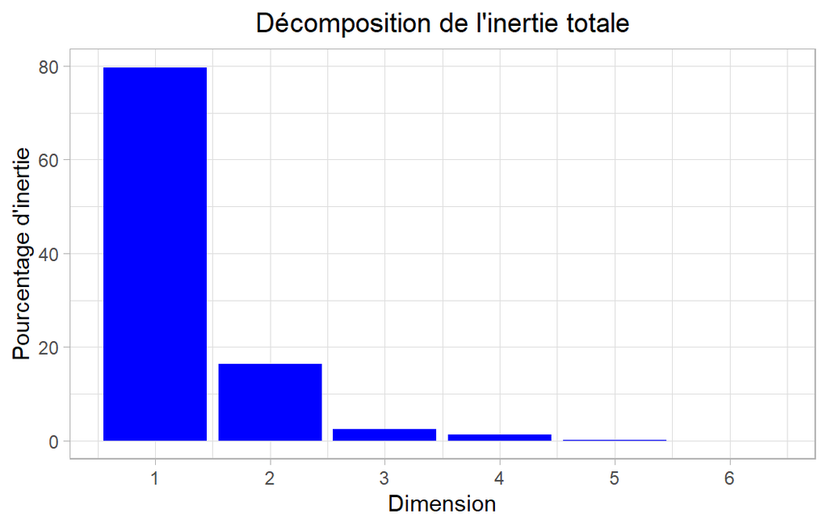

**Figure 2 - Décomposition de l’inertie totale** *Le premier facteur est prépondérant : il explique a lui seul 79.76% de la variabilité totale des données.* *Il convient de noter que dans un tel cas, la variabilité liée aux autres composantes peut être dénuée de sens, en dépit d’un pourcentage élevé.*

Une estimation du nombre pertinent d’axes à interpréter suggère de restreindre l’analyse à la description des 1 premiers axes. Ces composantes révèlent un taux d’inertie supérieur à celle du quantile 0.95-quantile de distributions aléatoires (79.76% contre 26.19%). Cette observation suggère que seul cet axe est porteur d’une véritable information. En conséquence, la description de l’analyse sera restreinte à ces seuls axes.

### 3. Description de la dimension 1

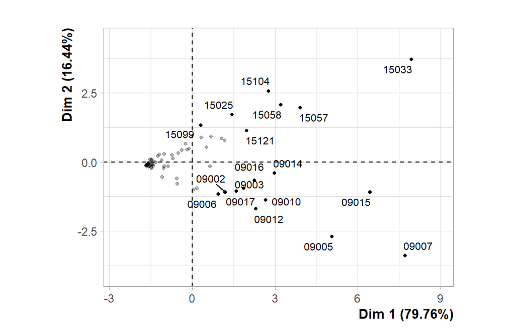

**Figure 3.1 - Graphe des individus (ACP)** *Les individus libellés sont ceux ayant la plus grande contribution à la construction du plan.*

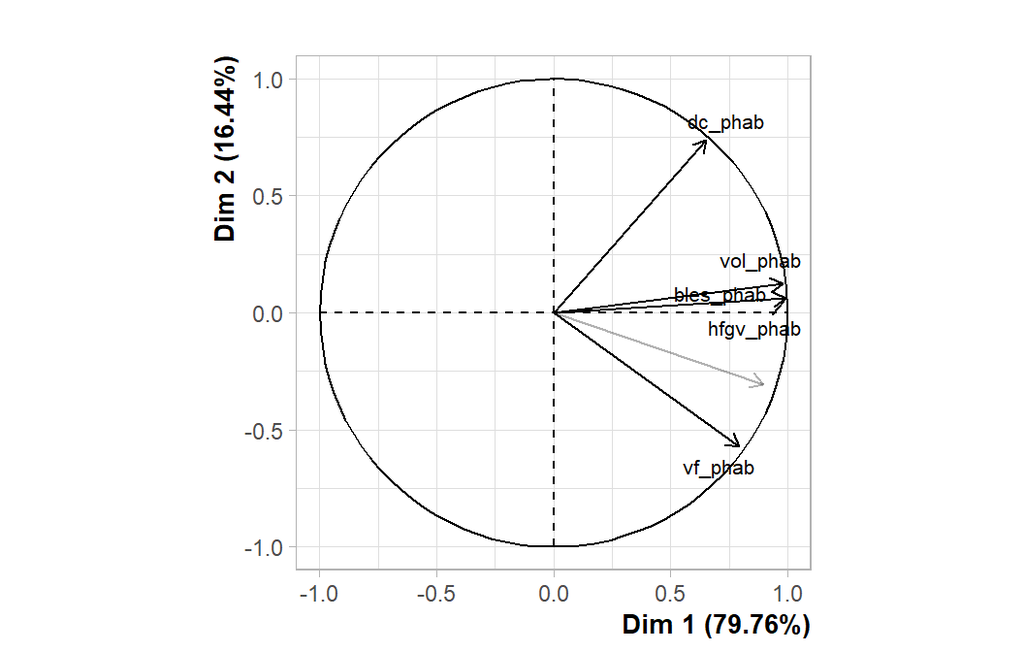

**Figure 3.2 - Graphe des variables (ACP)** *Les variables libellées sont celles les mieux représentées sur le plan.*

La **dimension 1** oppose des individus tels que *15057*, *09002*, *09007*, *15104*, *15121*, *15033*, *09010*, *09012*, *09015* et *09005* (à droite du graphe, caractérisés par une coordonnée fortement positive sur l’axe) à des individus caractérisés par une coordonnée fortement négative sur l’axe (à gauche du graphe).

Le groupe auquel les individus *15057*, *09002*, *15104*, *15121*, *09010*, *09012* et *15058* appartiennent (caractérisés par une coordonnée positive sur l’axe) partage :

- de fortes valeurs pour les variables *dc_phab*, *hfgv_phab*, *bles_phab*, *vol_phab* et *sec_phab* (de la plus extrême à la moins extrême).

Le groupe auquel les individus *09007*, *15033*, *09015* et *09005* appartiennent (caractérisés par une coordonnée positive sur l’axe) partage :

- de fortes valeurs pour les variables *hfgv_phab*, *bles_phab*, *sec_phab*, *vol_phab*, *vf_phab* et *dc_phab* (de la plus extrême à la moins extrême).

Le groupe 3 (caractérisés par une coordonnées négative sur l’axe) partage :

- de faibles valeurs pour les variables *hfgv_phab*, *bles_phab*, *vol_phab*, *sec_phab*, *dc_phab* et *vf_phab* (de la plus extrême à la moins extrême).

Notons que les variables *bles_phab*, *hfgv_phab* et *vol_phab* sont extrêmement corrélées à cette dimension (corrélations respectives de 0.99, 0.99, 0.96). Ces variables pourraient donc résumer à elles seules la dimension 1.

### 4. Classification

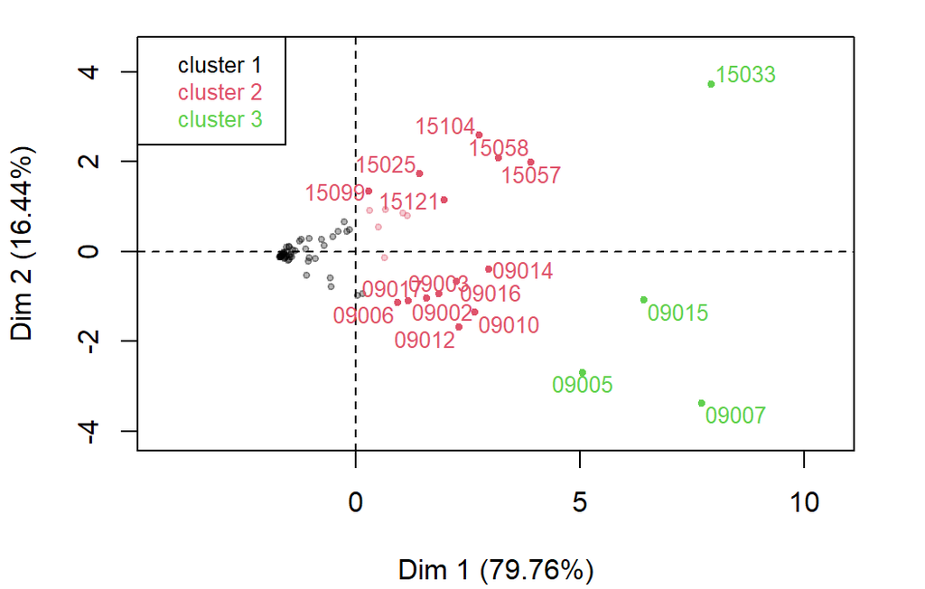

**Figure 4 - Classification Ascendante Hiérachique des individus.** *La classification réalisée sur les individus fait apparaître 3 classes.*

La **classe 1** est composé d’individus partageant :

- de faibles valeurs pour les variables *hfgv_phab*, *bles_phab*, *vol_phab*, *sec_phab*, *dc_phab* et *vf_phab* (de la plus extrême à la moins extrême).

La **classe 2** est composée d’individus tels que *09002*, *09003*, *09006*, *09010*, *09012*, *09014*, *09016*, *09017*, *15025* et *15057*. Ce groupe est caractérisé par :

- de fortes valeurs pour les variables *dc_phab*, *hfgv_phab*, *bles_phab*, *sec_phab*, *vol_phab* et *vf_phab* (de la plus extrême à la moins extrême).

La **classe 3** est composée d’individus tels que *09005*, *09007*, *09015* et *15033*. Ce groupe est caractérisé par :

- de fortes valeurs pour les variables *hfgv_phab*, *bles_phab*, *vol_phab*, *sec_phab*, *vf_phab* et *dc_phab* (de la plus extrême à la moins extrême).